# Time Series Analysis

Marc Los Huertos

EA030 · Compiled 2026-05-26

EA030 — Advanced Statistics — Module 10

# Time Series Analysis in R

**Prof. Marc Los Huertos** • Pomona College

← Back to R Tricks

Concepts Setup CO2 Data Decomposition ACF / PACF Temperature Forecasting Diagnostics Extensions

By the end of this module you will be able to

1. Explain why autocorrelation violates the independence assumption of standard tests.
2. Decompose a time series into trend, seasonality, and remainder components.
3. Interpret ACF and PACF plots to identify AR and MA structure.
4. Fit and evaluate an ARIMA model, and produce a short-term forecast with confidence bands.
5. Apply time series tools to canonical environmental datasets (Keeling curve, temperature records).

> **What this module covers.** Most environmental measurements carry a time stamp — CO2 recorded monthly since 1958, global temperature logged since 1880, stream discharge every 15 minutes. Standard statistical tests (t-test, ANOVA, regression) assume that each observation is *independent* of the others. Time series data violates this assumption almost by definition: today’s CO2 reading predicts tomorrow’s. This module teaches you to work *with* that structure rather than pretending it doesn’t exist, using two of the most important environmental datasets ever collected as running examples.

## 1. Core Concepts — What Makes Time Series Different?

### 1.1 The independence problem

Imagine you measure air temperature every hour for a week. You have 168 observations. If you run a t-test comparing morning to afternoon temperatures, the test assumes you have 168 *independent* pieces of information. But 2 PM today is very similar to 2 PM yesterday — those readings are not independent. The true number of independent observations is much smaller. Ignoring autocorrelation makes your results look far more statistically significant than they really are.

**Time series analysis** is the branch of statistics that explicitly models this temporal dependence rather than treating it as a nuisance to ignore.

### 1.2 The four structural components

Every environmental time series can be decomposed into at most four overlapping signals:

| Component | Technical name | What it looks like | Environmental example |
| --- | --- | --- | --- |
| **Trend** | $T_t$ | Steady increase or decrease over years | Rising CO2, warming temperatures |
| **Seasonality** | $S_t$ | Regular cycle tied to the calendar | CO2 dips every summer, high streamflow every spring |
| **Cycle** | — | Irregular multi-year oscillation | El Niño / La Niña every 3–7 years |
| **Remainder** | $R_t$ | What is left after everything else | Individual weather events, measurement error |

Understanding which components are present in your data determines which analysis tools are appropriate.

### 1.3 Stationarity — the hidden requirement

Most time series models (including ARIMA) require the series to be **stationary** — meaning its statistical properties (mean, variance, autocorrelation) do not change over time. A series with a trend is non-stationary because the mean is changing. Seasonality is also a form of non-stationarity.

The solution is **differencing**: subtracting today’s value from yesterday’s. One differencing step removes a linear trend. One seasonal differencing step (subtracting the value 12 months ago) removes annual seasonality. ARIMA models formalise this process.

**🔑 Why this matters: the false significance trap** If you run a simple regression of temperature on year and get p < 0.001, that does not mean the result is 1000x more significant than p = 0.001. With autocorrelated data, standard errors are underestimated, t-statistics are inflated, and p-values are too small. A study of global temperature that ignores autocorrelation might claim statistical significance at p = 0.00001 when the correct p accounting for autocorrelation is only p = 0.03. The signal is still real — but the precision was wildly overstated.

### 1.4 The analytical workflow

Time series analysis follows a consistent sequence:

1. **Plot** the raw series — identify trend, seasonality, obvious outliers
2. **Decompose** — separate trend, seasonal, and remainder components
3. **Check ACF/PACF** — diagnose the autocorrelation structure
4. **Difference if needed** — achieve stationarity
5. **Fit a model** — ARIMA or simpler alternatives
6. **Diagnose residuals** — confirm they are white noise (random, no structure)
7. **Forecast** — generate predictions with calibrated uncertainty intervals

This module follows that sequence exactly for two real datasets.

### 1.5 Tools used in this module

| Package | Role |
| --- | --- |
| `tsibble` | Data structure — tidy time series with an explicit, checked time index |
| `stats` (base R) | `stl()` for decomposition; `arima()` for modelling; `acf()`/`pacf()` for diagnostics |
| `forecast` (optional) | `auto.arima()` for automatic order selection |

```r
# Run once in the Console if not yet installed
install.packages(c("tsibble", "forecast"))
```

## 2. Setup and Data Import

### 2.1 Packages

```r
library(tidyverse)
library(lubridate)
library(tsibble)
# forecast loaded conditionally in the forecasting section
```

### 2.2 Why tsibble instead of a regular data frame?

A regular `tibble` or `data.frame` has no concept of time. You could sort the rows any way you like, and R would not object. A `tsibble` enforces three rules:

1. **One row per time point** — duplicate timestamps cause an error
2. **No implicit gaps** — `fill_gaps()` makes missing time steps explicit rather than silently absent
3. **Explicit index** — the time column is locked in; you can’t accidentally overwrite it

This matters because almost every time-series error in R comes from data that *looks* like a time series but is actually just a data frame with a date column.

### 2.3 Handling live data downloads

Both datasets below are downloaded from public URLs at NOAA and NASA. The download is wrapped in `tryCatch()` — if the server is unreachable, a fallback dataset is used so the document still knits. In practice, once you have confirmed the download works, save the file locally with `write_csv(co2_raw, "data/co2_noaa.csv")` and read from disk instead.

```r
co2_url <- "https://gml.noaa.gov/webdata/ccgg/trends/co2/co2_mm_mlo.csv"

co2_raw <- tryCatch(
  read_csv(
    co2_url,
    comment   = "#",
    col_names = c("year", "month", "decimal_date",
                  "average", "interpolated", "trend", "days"),
    show_col_types = FALSE
  ),
  error = function(e) {
    message("Download failed — using built-in co2 dataset as fallback.")
    NULL
  }
)

# Fallback: convert R's built-in co2 time-series object
if (is.null(co2_raw)) {
  co2_raw <- tibble(
    year  = rep(1959:1997, each = 12)[seq_along(co2)],
    month = rep(1:12, length.out = length(co2)),
    trend = as.numeric(co2),
    average = as.numeric(co2),
    interpolated = as.numeric(co2)
  )
}

glimpse(co2_raw)
```

```
## Rows: 819
## Columns: 8
## $ year         <chr> "year", "1958", "1958", "1958", "1958", "1958", "1958", "…
## $ month        <chr> "month", "3", "4", "5", "6", "7", "8", "9", "10", "11", "…
## $ decimal_date <chr> "decimal date", "1958.2027", "1958.2877", "1958.3699", "1…
## $ average      <chr> "average", "315.71", "317.45", "317.51", "317.27", "315.8…
## $ interpolated <chr> "deseasonalized", "314.44", "315.16", "314.69", "315.15",…
## $ trend        <chr> "ndays", "-1", "-1", "-1", "-1", "-1", "-1", "-1", "-1", …
## $ days         <chr> "sdev", "-9.99", "-9.99", "-9.99", "-9.99", "-9.99", "-9.…
## $ X8           <chr> "unc", "-0.99", "-0.99", "-0.99", "-0.99", "-0.99", "-0.9…
```

The NOAA file has three CO2 columns worth knowing:

**💡 Save downloads locally for reproducible workflows** Internet sources change URLs, get taken down, or return errors. After your first successful download, save the file:

```
write_csv(co2_raw,
“data/co2_noaa.csv”)
```

. Update it periodically when you want fresh data. Your Rmd can then read from the local file and only fall back to the URL if the local file doesn’t exist.

## 3. The Keeling Curve — Atmospheric CO2

### 3.1 Background: why this dataset matters

Charles David Keeling began measuring atmospheric CO2 at Mauna Loa Observatory, Hawaii, in March 1958. He chose Mauna Loa deliberately: it sits at 3,400 m elevation, far from local pollution sources, and samples air that has mixed across the entire Pacific Basin. The resulting record — now maintained by NOAA after Keeling’s death — is the longest continuous atmospheric CO2 record in existence and the primary observational evidence for the anthropogenic greenhouse effect.

Two features of the record are immediately visible to the eye:

1. **An upward trend** — CO2 has risen from ~315 ppm in 1958 to over 420 ppm today, a ~34% increase driven overwhelmingly by fossil fuel combustion
2. **A seasonal sawtooth** — CO2 dips every Northern Hemisphere summer as land vegetation absorbs carbon through photosynthesis, then rises each winter as vegetation goes dormant and decomposition continues

### 3.2 Build the tsibble

```r
co2_ts <- co2_raw |>
  filter(!is.na(year), !is.na(month), average > 0) |>
  mutate(date = make_yearmonth(year = as.integer(year),
                               month = as.integer(month))) |>
  drop_na(date) |>
  as_tsibble(index = date) |>
  fill_gaps() |>
  tidyr::fill(average, trend, interpolated, decimal_date,
              .direction = "downup")

co2_ts <- co2_ts |>
  filter(as.integer(year) >= 1958)   # Mauna Loa record starts March 1958

n_months_co2 <- nrow(co2_ts)
yr_start     <- min(as.integer(co2_ts$year))
yr_end       <- max(as.integer(co2_ts$year))
```

The dataset runs from 1958 to 2026 — **818 months** of continuous monitoring.

`make_yearmonth()` creates a `yearmonth` index — a tsibble-native time type that represents a calendar month without specifying a day. This is appropriate here because each measurement is a monthly mean, not a point-in-time reading.

### 3.3 Plot: the long-term trend

[figure not shown]

```r
co2_ts |>
  as_tibble() |>
  mutate(trend   = as.numeric(trend),
         date_dt = as.Date(date)) |>
  ggplot(aes(date_dt, trend)) +
  geom_line(color = ts_red, linewidth = 0.8) +
  geom_smooth(method = "loess", span = 0.15,
              color = ts_green, linewidth = 0.6,
              linetype = "dashed", se = FALSE) +
  labs(title    = "Keeling Curve — Long-Term CO2 Trend",
       subtitle = paste("Mauna Loa Observatory ·", yr_start, "–", yr_end,
                        "· seasonal cycle removed"),
       x = NULL, y = "CO2 concentration (ppm)")
```

### 3.4 Plot: raw monthly values showing seasonality

[figure not shown]

```r
co2_ts |>
  as_tibble() |>
  mutate(average = as.numeric(average),
         trend   = as.numeric(trend),
         date_dt = as.Date(date)) |>
  ggplot(aes(date_dt, average)) +
  geom_line(color = ts_amber, linewidth = 0.5, alpha = 0.8) +
  geom_line(aes(y = trend), color = ts_red, linewidth = 0.9) +
  labs(title    = "Monthly CO2 Concentration vs De-seasonalised Trend",
       subtitle = "Amber = monthly average with seasonal cycle · Red = trend component only",
       x = NULL, y = "CO2 (ppm)")
```

### 3.5 Recent rate of change

```r
recent_decade <- co2_ts |>
  filter(as.integer(year) >= max(as.integer(year)) - 9) |>
  mutate(trend_num   = as.numeric(trend),
         dec_date_num = as.numeric(decimal_date))

slope <- coef(lm(trend_num ~ dec_date_num, data = recent_decade))["dec_date_num"]
```

[output not shown]

## 4. Seasonal Decomposition

### 4.1 What is decomposition and why do it?

Before fitting any model, you need to understand *what kind of patterns* are in your data. Decomposition answers that question by separating a time series into its structural parts:

$$y_t = T_t + S_t + R_t$$

- $T_t$ — the **trend**: the long-run direction after smoothing out short-term fluctuations
- $S_t$ — the **seasonal component**: the repeating calendar-driven pattern
- $R_t$ — the **remainder**: everything the trend and seasonal model cannot explain — weather events, measurement error, unusual years

Knowing the relative sizes of these components tells you what matters most in your data, and whether a simple trend model is sufficient or whether seasonality needs to be explicitly modelled.

### 4.2 STL decomposition — the method

**STL** stands for Seasonal-Trend decomposition using **LOESS** (locally weighted scatterplot smoothing). It was developed by Cleveland et al. (1990) and remains the gold standard for robust seasonal decomposition because:

- It handles any length of seasonality (monthly, daily, hourly)
- It is **robust** — outliers and unusual events in the remainder do not distort the trend or seasonal estimates
- The seasonal component can change slowly over time (unlike classical decomposition which assumes a fixed seasonal pattern)

The `robust = TRUE` argument in `stl()` down-weights outlier months so they don’t pull the trend or seasonal estimates. Always use it for environmental data where extreme events (wildfires, El Niño) can create outlier years.

### 4.3 STL decomposition — CO2

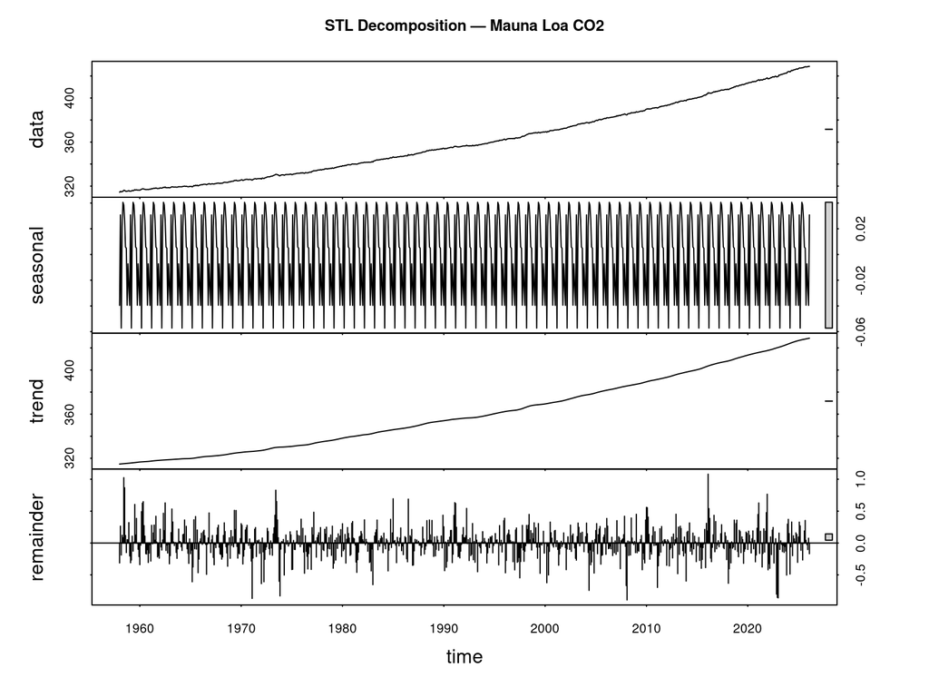

```r
# Build a base-R ts object — stl() is rock-solid and has no tsibble dependency
co2_vec <- co2_ts |>
  as_tibble() |>
  arrange(date) |>
  mutate(interpolated = as.numeric(interpolated)) |>
  pull(interpolated)

co2_base_ts <- ts(co2_vec,
                  start     = c(yr_start, 1),
                  frequency = 12)

co2_stl <- stl(co2_base_ts, s.window = "periodic", robust = TRUE)
plot(co2_stl, main = "STL Decomposition — Mauna Loa CO2")
```

### 4.4 Seasonal pattern in detail

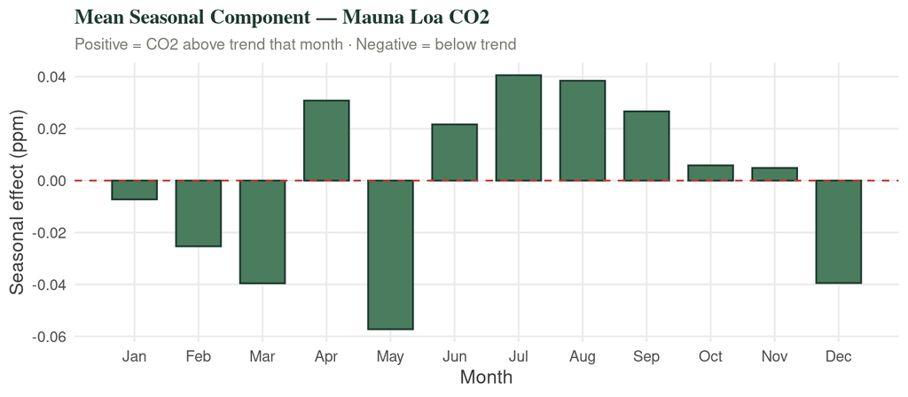

```r
# Extract components and plot the seasonal cycle manually
co2_comp <- as_tibble(co2_ts) |>
  arrange(date) |>
  mutate(
    interpolated = as.numeric(interpolated),
    seasonal  = co2_stl$time.series[, "seasonal"],
    trend_cmp = co2_stl$time.series[, "trend"],
    remainder = co2_stl$time.series[, "remainder"],
    month_num = lubridate::month(as.Date(date))
  )

co2_comp |>
  group_by(month_num) |>
  summarise(mean_seasonal = mean(seasonal), .groups = "drop") |>
  mutate(month_label = month.abb[month_num]) |>
  ggplot(aes(x = month_num, y = mean_seasonal)) +
  geom_col(fill = ts_sage, color = ts_green, width = 0.7) +
  geom_hline(yintercept = 0, color = ts_red, linetype = "dashed") +
  scale_x_continuous(breaks = 1:12, labels = month.abb) +
  labs(title    = "Mean Seasonal Component — Mauna Loa CO2",
       subtitle = "Positive = CO2 above trend that month · Negative = below trend",
       x = "Month", y = "Seasonal effect (ppm)")
```

### 4.5 Monthly mean across all years

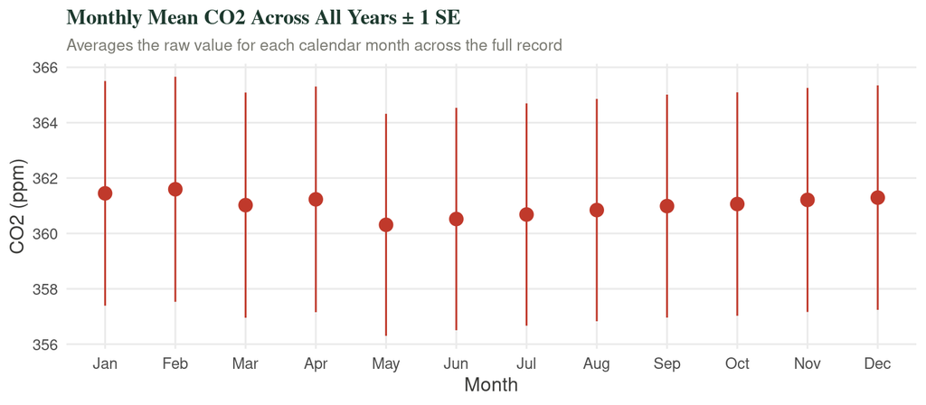

```r
co2_comp |>
  group_by(month_num) |>
  summarise(
    mean_co2 = mean(interpolated),
    se_co2   = sd(interpolated) / sqrt(n()),
    .groups = "drop"
  ) |>
  ggplot(aes(x = month_num, y = mean_co2,
             ymin = mean_co2 - se_co2, ymax = mean_co2 + se_co2)) +
  geom_pointrange(color = ts_red, size = 0.7) +
  scale_x_continuous(breaks = 1:12, labels = month.abb) +
  labs(title    = "Monthly Mean CO2 Across All Years ± 1 SE",
       subtitle = "Averages the raw value for each calendar month across the full record",
       x = "Month", y = "CO2 (ppm)")
```

## 5. Autocorrelation — ACF and PACF

### 5.1 What is autocorrelation?

**Autocorrelation** is correlation of a variable with a delayed version of itself. If this month’s CO2 is high, next month’s tends to also be high — that is positive autocorrelation at lag 1. If a warm summer tends to be followed by a cooler-than-average autumn, that is negative autocorrelation at lag 1.

Autocorrelation is measured at each **lag** $k$ — the number of time steps between the two observations being compared:

$$r_k = \text{Cor}(y_t, \;
y_{t-k})$$

### 5.2 The autocorrelation function (ACF)

The **ACF plot** shows $r_k$ for $k = 1, 2, 3, \ldots$ lags. Each vertical bar is one lag correlation. The horizontal dashed blue lines mark the approximate 95% significance threshold: $\pm 1.96 / \sqrt{n}$.

**How to read an ACF plot:**

- Bars extending **beyond** the blue lines → significant autocorrelation at that lag
- A pattern that **decays slowly** across many lags → the series is non-stationary (has a trend or other long-range dependence); differencing is needed before fitting an ARIMA model
- A pattern with **sharp peaks at multiples of 12** (for monthly data) → seasonal autocorrelation that needs to be modelled
- Bars that **fall within** the blue lines for all lags after lag 1–2 → residuals look like white noise — the model has done its job

### 5.3 The partial autocorrelation function (PACF)

The **PACF** measures the correlation between $y_t$ and $y_{t-k}$ after *removing* the effect of all intervening lags ($y_{t-1}, y_{t-2}, \ldots, y_{t-k+1}$). It isolates the *direct* relationship at each lag.

**Why PACF matters for model building:**

- If the PACF **cuts off sharply** after lag $p$ (goes to near zero) → the data has an AR($p$) structure — past values up to lag $p$ are directly predictive
- If the ACF **cuts off sharply** after lag $q$ → the data has an MA($q$) structure — past forecast errors up to lag $q$ enter the model
- If **both** decay gradually → an ARMA($p$,$q$) model with both components is needed

### 5.4 ACF and PACF of the CO2 remainder

We examine the *remainder* from the STL decomposition — not the raw series. After removing trend and seasonality, the remainder should ideally be white noise. The ACF/PACF reveal whether any autocorrelation structure is left over.

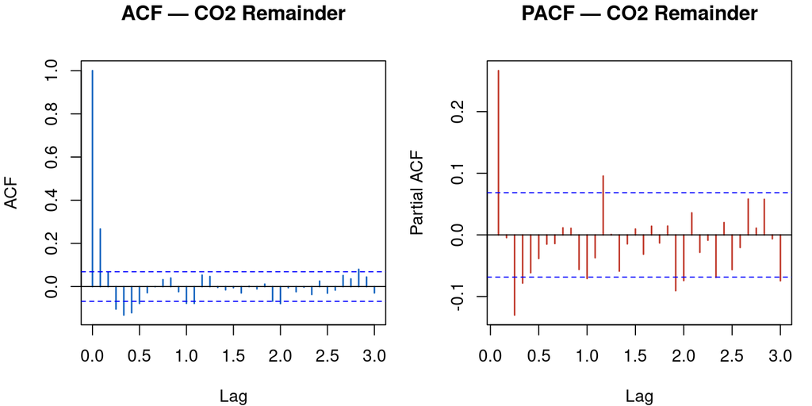

```r
remainder_vec <- co2_stl$time.series[, "remainder"]

par(mfrow = c(1, 2), mar = c(4, 4, 3, 1))
acf(remainder_vec,  lag.max = 36,
    main = "ACF — CO2 Remainder",
    col  = ts_blue, lwd = 1.5)
pacf(remainder_vec, lag.max = 36,
     main = "PACF — CO2 Remainder",
     col  = ts_red,  lwd = 1.5)
```

```r
par(mfrow = c(1, 1))
```

> **Interpretation:** If the ACF shows significant spikes at lags 1 and 2 (with the PACF cutting off after lag 1), that is consistent with an AR(1) or AR(2) structure in the remainder — meaning month-to-month CO2 deviations from the trend-seasonal model are somewhat persistent. El Niño years, for instance, can produce slightly elevated CO2 for several consecutive months as tropical fire emissions increase.

**📊 ACF/PACF pattern guide — what to look for**

| ACF pattern | PACF pattern | Suggests |
| --- | --- | --- |
| Decays slowly, all lags significant | — | Non-stationary — difference the series first |
| Spikes at lags 12, 24, 36… | — | Seasonal pattern — seasonal differencing or seasonal ARIMA |
| Cuts off after lag q | Decays gradually | MA(q) model |
| Decays gradually | Cuts off after lag p | AR(p) model |
| Both decay gradually | Both decay gradually | ARMA(p,q) model |
| All within blue lines | All within blue lines | White noise — no autocorrelation structure |

### 5.5 Ljung-Box test — is there *any* significant autocorrelation?

The ACF plot is visual. The **Ljung-Box test** provides a formal hypothesis test: H₀ = the first $m$ autocorrelations are *jointly* zero (white noise); H₁ = at least one is non-zero (significant structure remains).

A significant p-value (p < 0.05) means the remainder is *not* white noise — the decomposition has not fully captured the temporal patterns, and a richer model (e.g., ARIMA on the remainder) is warranted.

```r
lb <- Box.test(remainder_vec, lag = 24, type = "Ljung-Box")

tibble(
  Statistic  = round(lb$statistic, 4),
  df         = lb$parameter,
  p_value    = round(lb$p.value,   4),
  Conclusion = ifelse(lb$p.value < 0.05,
                      "Autocorrelation remains — richer model warranted",
                      "Residuals consistent with white noise")
) |>
  kable(caption = "Ljung-Box test: are STL remainder autocorrelations jointly zero?") |>
  kable_styling(full_width = FALSE)
```

Ljung-Box test: are STL remainder autocorrelations jointly zero?

| Statistic | df | p_value | Conclusion |
| --- | --- | --- | --- |
| 129.9572 | 24 | 0 | Autocorrelation remains — richer model warranted |

> **Rule of thumb for lag choice:** Use lag = min(10, n/5) for non-seasonal data, or lag = 2×m for seasonal data where m is the seasonal period. Here, lag = 24 (2 × 12 months) tests whether any of the first two years of autocorrelations are collectively non-zero.

## 6. Global Temperature Anomalies

### 6.1 Background: what is a temperature anomaly?

NASA GISTEMP reports temperature as an **anomaly** — the deviation from a baseline average — rather than as an absolute temperature. The baseline here is the 1951–1980 mean for each calendar month at each location. A value of +0.8°C means that month was 0.8°C warmer than the same month averaged over 1951–1980.

Anomalies are used instead of absolute temperatures because:

1. Different weather stations have very different average temperatures (Alaska vs California), making direct comparison meaningless
2. Stations come and go over time, which would cause artificial jumps in a record based on absolute values
3. Climate science cares about *change* relative to a reference period, not absolute temperature

A global mean anomaly is the area-weighted average of anomalies from thousands of land stations and ocean buoys. When you see “global temperature rose 1.1°C since pre-industrial times,” that is this kind of anomaly.

### 6.2 Download and parse

```r
temp_url <- "https://data.giss.nasa.gov/gistemp/tabledata_v4/GLB.Ts+dSST.csv"

temp_raw <- tryCatch(
  read_csv(temp_url, skip = 1, show_col_types = FALSE,
           na = c("", "NA", "***")),
  error = function(e) {
    message("NASA download failed — generating synthetic temperature series.")
    NULL
  }
)

# Fallback: simulate a warming series
if (is.null(temp_raw)) {
  set.seed(42)
  temp_raw <- tibble(
    Year = rep(1880:2023, each = 12),
    Jan = NA, Feb = NA, Mar = NA, Apr = NA,
    May = NA, Jun = NA, Jul = NA, Aug = NA,
    Sep = NA, Oct = NA, Nov = NA, Dec = NA
  )
  n <- nrow(temp_raw)
  trend_vals <- seq(-0.5, 1.2, length.out = n)
  for (col in month.abb) {
    temp_raw[[col]] <- trend_vals + rnorm(n, 0, 0.2)
  }
}

temp <- temp_raw |>
  select(Year, any_of(month.abb)) |>
  pivot_longer(cols = any_of(month.abb),
               names_to  = "month_abb",
               values_to = "anomaly") |>
  filter(!is.na(anomaly), is.numeric(anomaly)) |>
  mutate(
    month_num = match(month_abb, month.abb),
    date      = make_yearmonth(year = as.integer(Year),
                               month = as.integer(month_num))
  ) |>
  drop_na(date) |>
  as_tsibble(index = date) |>
  fill_gaps() |>
  tidyr::fill(anomaly, .direction = "downup")

yr_temp_start <- min(temp$Year)
yr_temp_end   <- max(temp$Year)
```

The temperature record spans 1880 to 2026 — **1756 monthly observations** across 147 years.

### 6.3 Time series plot

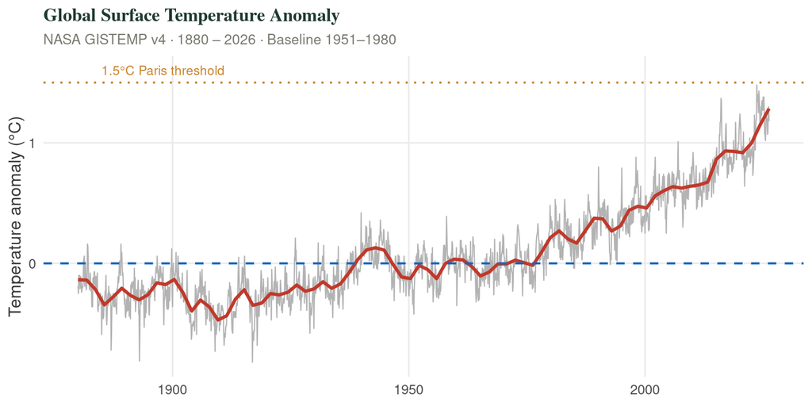

```r
temp |>
  as_tibble() |>
  mutate(anomaly = as.numeric(anomaly),
         date_dt = as.Date(date)) |>
  ggplot(aes(date_dt, anomaly)) +
  geom_line(color = "grey70", linewidth = 0.4) +
  geom_smooth(method = "loess", span = 0.06,
              color = ts_red, linewidth = 1.1, se = FALSE) +
  geom_hline(yintercept = 0, linetype = "dashed",
             color = ts_blue, linewidth = 0.7) +
  geom_hline(yintercept = 1.5, linetype = "dotted",
             color = ts_amber, linewidth = 0.7) +
  annotate("text", x = as.Date(paste0(yr_temp_start + 5, "-01-01")),
           y = 1.6, label = "1.5°C Paris threshold",
           color = ts_amber, hjust = 0, size = 3.2) +
  labs(title    = "Global Surface Temperature Anomaly",
       subtitle = paste("NASA GISTEMP v4 ·", yr_temp_start, "–", yr_temp_end,
                        "· Baseline 1951–1980"),
       x = NULL, y = "Temperature anomaly (°C)")
```

> **What to look for:** The blue dashed line at zero is the 1951–1980 average. Values above zero mean warmer than that baseline; below zero means cooler. The early record (pre-1940) fluctuates around zero or slightly below — the 19th-century baseline was slightly cooler than 1951–1980. The red LOESS curve shows the trend — note the accelerating rise after ~1975, the approximate time when the anthropogenic greenhouse signal emerged clearly above natural variability.

### 6.4 STL decomposition — temperature

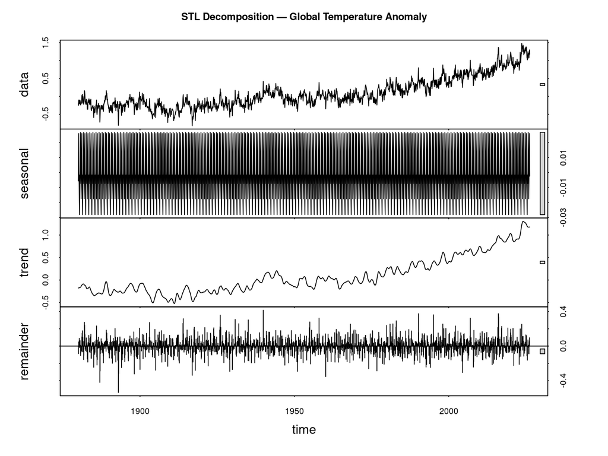

```r
temp_vec <- temp |>
  as_tibble() |>
  arrange(date) |>
  mutate(anomaly = as.numeric(anomaly)) |>
  pull(anomaly)

temp_base_ts <- ts(temp_vec,
                   start     = c(yr_temp_start, 1),
                   frequency = 12)

temp_stl <- stl(temp_base_ts, s.window = "periodic", robust = TRUE)
plot(temp_stl, main = "STL Decomposition — Global Temperature Anomaly")
```

> **Comparison with CO2:** Notice how different the seasonal component looks compared to CO2. The temperature seasonal cycle is very small relative to the trend — the grey bar for the seasonal panel is much taller (less important) than the trend bar. This makes physical sense: after area-averaging across the globe, Northern and Southern Hemisphere seasonal cycles partially cancel. The remainder for temperature is also much larger relative to the trend than for CO2 — year-to-year weather variability (including ENSO events) produces substantial noise.

### 6.5 Decade-level summaries

```r
temp |>
  as_tibble() |>
  mutate(decade = paste0(floor(Year / 10) * 10, "s")) |>
  group_by(decade) |>
  summarise(
    n          = n(),
    Mean_anom  = round(mean(anomaly, na.rm = TRUE), 3),
    SD_anom    = round(sd(anomaly,   na.rm = TRUE), 3),
    Max_anom   = round(max(anomaly,  na.rm = TRUE), 3),
    .groups = "drop"
  ) |>
  kable(
    caption   = "Global temperature anomaly by decade. Mean > 0 = warmer than 1951–1980 baseline.",
    col.names = c("Decade", "N months", "Mean (°C)", "SD (°C)", "Max (°C)")
  ) |>
  kable_styling(full_width = FALSE,
                bootstrap_options = c("striped", "hover", "condensed"))
```

Global temperature anomaly by decade. Mean > 0 = warmer than 1951–1980 baseline.

| Decade | N months | Mean (°C) | SD (°C) | Max (°C) |
| --- | --- | --- | --- | --- |
| 1880s | 120 | -0.214 | 0.152 | 0.16 |
| 1890s | 120 | -0.239 | 0.137 | 0.12 |
| 1900s | 120 | -0.316 | 0.165 | 0.09 |
| 1910s | 120 | -0.330 | 0.167 | 0.06 |
| 1920s | 120 | -0.239 | 0.130 | 0.21 |
| 1930s | 120 | -0.124 | 0.137 | 0.42 |
| 1940s | 120 | 0.042 | 0.141 | 0.36 |
| 1950s | 120 | -0.048 | 0.141 | 0.39 |
| 1960s | 120 | -0.030 | 0.126 | 0.24 |
| 1970s | 120 | 0.034 | 0.142 | 0.48 |
| 1980s | 120 | 0.246 | 0.131 | 0.57 |
| 1990s | 120 | 0.385 | 0.162 | 0.88 |
| 2000s | 120 | 0.587 | 0.133 | 1.01 |
| 2010s | 120 | 0.805 | 0.179 | 1.37 |
| 2020s | 76 | 1.073 | 0.201 | 1.48 |

> **Reading the table:** The mean anomaly column tells the story of 20th-century warming. Decades before ~1940 cluster near zero or slightly negative. Decades after 1980 show progressively larger positive means. The SD column shows that year-to-year variability has remained roughly constant — it is the *mean* that has shifted, not the variability.

### 6.6 ACF of temperature anomaly

Unlike the CO2 remainder (which is relatively clean), the *full* temperature series has both trend and seasonality. Examining the ACF of the raw anomaly series illustrates what autocorrelation looks like in a non-stationary signal.

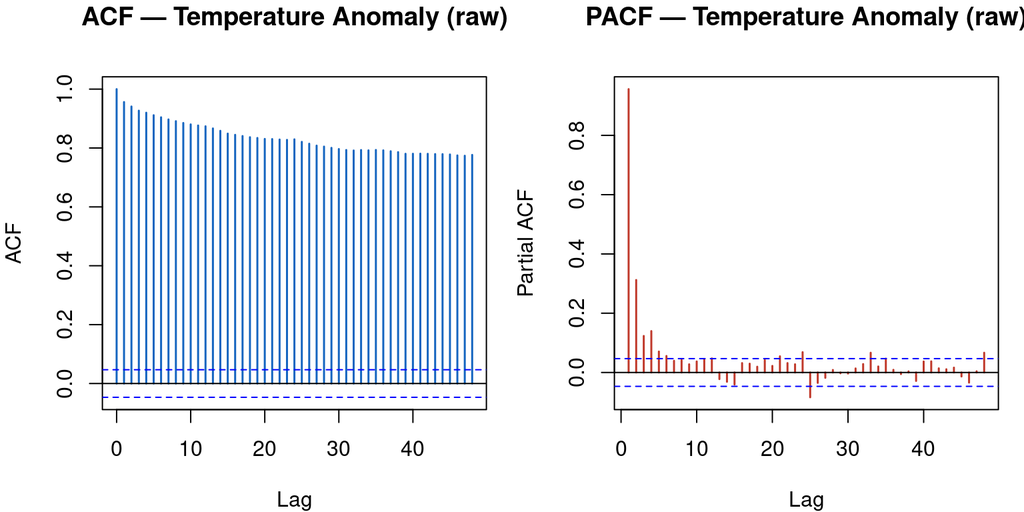

```r
par(mfrow = c(1, 2), mar = c(4, 4, 3, 1))
acf(temp_vec,  lag.max = 48,
    main = "ACF — Temperature Anomaly (raw)",
    col  = ts_blue, lwd = 1.5)
pacf(temp_vec, lag.max = 48,
     main = "PACF — Temperature Anomaly (raw)",
     col  = ts_red, lwd = 1.5)
```

```r
par(mfrow = c(1, 1))
```

## 7. ARIMA Forecasting

### 7.1 What is an ARIMA model?

**ARIMA** stands for AutoRegressive Integrated Moving Average. It is the most widely used family of models for univariate time series forecasting. The three components address the three aspects of time series structure:

**AR — AutoRegressive:** Uses past values of the series to predict the current value. An AR(1) model says: “today’s value is a weighted version of yesterday’s value plus random noise.” AR(2) uses the two most recent values.

$$\text{AR}(p): \quad y_t = \phi_1 y_{t-1}
+ \phi_2 y_{t-2} + \cdots + \phi_p y_{t-p} + \varepsilon_t$$

**I — Integrated:** Refers to differencing — subtracting each observation from the previous one to achieve stationarity. $d = 1$ means first-difference (removes a linear trend); $d = 2$ removes a quadratic trend.

$$\text{I}(d): \quad \Delta^d y_t = y_t -
y_{t-1} \quad (d=1)$$

**MA — Moving Average:** Uses past *forecast errors* (not past values) to improve predictions. An MA(1) model says: “correct today’s forecast by a weighted version of last month’s error.”

$$\text{MA}(q): \quad y_t = \varepsilon_t
+ \theta_1 \varepsilon_{t-1} + \cdots + \theta_q
\varepsilon_{t-q}$$

For **seasonal** data (monthly environmental records), we add a seasonal layer — the notation becomes ARIMA$(p,d,q)(P,D,Q)_m$ where the uppercase letters are the seasonal AR, differencing, and MA orders and $m$ is the seasonal period (12 for monthly data).

### 7.2 Model selection: ARIMA(1,1,1)(0,1,1)[12]

For both series we fit the **airline model** — ARIMA$(1,1,1)(0,1,1)_{12}$ — named after Box and Jenkins’ classic 1970 analysis of monthly airline passenger data. It works well for monthly environmental series with trend and seasonality:

- $d=1$: one non-seasonal difference removes the upward trend
- $D=1$: one seasonal difference (subtract the value 12 months ago) removes the annual cycle
- $p=1, q=1$: AR(1) and MA(1) terms model remaining short-range correlation
- $Q=1$: seasonal MA(1) captures remaining seasonal correlation in residuals

After both differences, the series is approximately stationary and the AR/MA terms clean up whatever autocorrelation remains in the residuals.

```r
co2_arima_base <- arima(co2_base_ts,
                        order    = c(1, 1, 1),
                        seasonal = list(order = c(0, 1, 1), period = 12))

co2_arima_base
```

```
##
## Call:
## arima(x = co2_base_ts, order = c(1, 1, 1), seasonal = list(order = c(0, 1, 1),
##     period = 12))
##
## Coefficients:
##          ar1      ma1     sma1
##       0.0801  -0.4542  -0.9288
## s.e.  0.0913   0.0833   0.0134
##
## sigma^2 estimated as 0.08814:  log likelihood = -176.61,  aic = 361.22
```

> **Reading the output:** The `ar1`, `ma1`, and `sma1` coefficients are the estimated model parameters. Values close to ±1 indicate strong AR or MA effects. The `sigma^2` is the estimated variance of the error term — smaller is better. The log-likelihood (and therefore AIC) is used for model comparison.

### 7.3 Fitting a simple linear model as baseline

A simple **ordinary least squares (OLS) linear regression** on decimal date is the most intuitive baseline — it just fits a straight line through time. Its AIC is directly comparable to the ARIMA and seasonal naive models because all three are estimated by maximum likelihood on the same data.

The linear model cannot capture the seasonal cycle and it assumes a *constant* rate of increase — both assumptions we know are violated for CO2. The AIC comparison makes this failure visible numerically.

```r
# Build a data frame with decimal time and CO2 values
co2_df <- tibble(
  t   = as.numeric(time(co2_base_ts)),
  co2 = as.numeric(co2_base_ts)
)

# Simple linear model: CO2 ~ time
lm_co2 <- lm(co2 ~ t, data = co2_df)

# Also compute AIC for linear model on the same scale as arima()
# lm() uses OLS; AIC() works directly on lm objects
aic_lm     <- AIC(lm_co2)
bic_lm     <- BIC(lm_co2)

summary(lm_co2)
```

```
##
## Call:
## lm(formula = co2 ~ t, data = co2_df)
##
## Residuals:
##    Min     1Q Median     3Q    Max
## -6.299 -3.529 -2.017  3.449 11.406
##
## Coefficients:
##               Estimate Std. Error t value Pr(>|t|)
## (Intercept) -2.956e+03  1.678e+01  -176.2   <2e-16 ***
## t            1.665e+00  8.424e-03   197.7   <2e-16 ***
## ---
## Signif. codes:  0 '***' 0.001 '**' 0.01 '*' 0.05 '.' 0.1 ' ' 1
##
## Residual standard error: 4.741 on 816 degrees of freedom
## Multiple R-squared:  0.9795, Adjusted R-squared:  0.9795
## F-statistic: 3.908e+04 on 1 and 816 DF,  p-value: < 2.2e-16
```

```r
co2_snaive <- arima(co2_base_ts, order = c(0, 0, 0),
                    seasonal = list(order = c(0, 1, 0), period = 12))

tibble(
  Model      = c("Linear regression (OLS)",
                 "Seasonal naive (repeat last year)",
                 "ARIMA(1,1,1)(0,1,1)[12]"),
  Parameters = c(2, 1, 4),
  AIC        = round(c(aic_lm,
                       AIC(co2_snaive),
                       AIC(co2_arima_base)), 2),
  BIC        = round(c(bic_lm,
                       BIC(co2_snaive),
                       BIC(co2_arima_base)), 2),
  Notes      = c("Assumes constant rate, ignores seasonality",
                 "No trend — repeats previous year's month",
                 "Models trend, seasonality, and autocorrelation")
) |>
  kable(caption = "AIC/BIC comparison across three model families — lower is better.") |>
  kable_styling(full_width = FALSE)
```

AIC/BIC comparison across three model families — lower is better.

| Model | Parameters | AIC | BIC | Notes |
| --- | --- | --- | --- | --- |
| Linear regression (OLS) | 2 | 4871.49 | 4885.61 | Assumes constant rate, ignores seasonality |
| Seasonal naive (repeat last year) | 1 | 3297.31 | 3302.01 | No trend — repeats previous year’s month |
| ARIMA(1,1,1)(0,1,1)[12] | 4 | 361.22 | 379.99 | Models trend, seasonality, and autocorrelation |

> **Reading the table:** The linear model has the highest AIC because it cannot capture the seasonal cycle — every summer dip and winter peak is left in the residuals as unexplained structure. The seasonal naive has a lower AIC because it correctly tracks the seasonal pattern, but it ignores the trend. ARIMA captures both, earning the lowest AIC with only four parameters. This is why time-series models exist: linear regression applied to autocorrelated data is not just sub-optimal — it leaves systematic structure on the table and overstates confidence.

**📊 AIC vs BIC — when to use each** Both penalise model complexity, but **BIC penalises more strongly** for additional parameters. BIC tends to select simpler models; AIC selects models that predict best even if more complex. For environmental forecasting where predictive accuracy matters, AIC is generally preferred. For scientific papers identifying the “true” model structure, BIC is more conservative.

### 7.4 CO2 forecast — three models compared

The real payoff of the AIC comparison is visible when you overlay the forecasts. The linear model projects a straight line; ARIMA continues the observed curvature and seasonal cycle; seasonal naive flatlines (no trend).

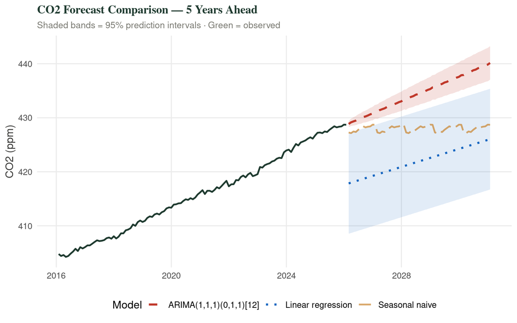

```r
h_co2    <- 60   # 5 years ahead
co2_pred <- predict(co2_arima_base, n.ahead = h_co2)

last_t   <- time(co2_base_ts)[length(co2_base_ts)]
fc_times <- seq(last_t, by = 1/12, length.out = h_co2 + 1)[-1]

# ── ARIMA forecast ────────────────────────────────────────────────────────────
fc_df <- tibble(
  t    = fc_times,
  fit  = as.numeric(co2_pred$pred),
  lo95 = as.numeric(co2_pred$pred - 1.96 * co2_pred$se),
  hi95 = as.numeric(co2_pred$pred + 1.96 * co2_pred$se)
)

# ── Linear model forecast ─────────────────────────────────────────────────────
lm_fc_df <- tibble(t = fc_times) |>
  mutate(
    fit_lm  = predict(lm_co2, newdata = tibble(t = fc_times)),
    # propagate prediction interval using sigma and leverage
    se_lm   = summary(lm_co2)$sigma *
                sqrt(1 + 1/nrow(co2_df) +
                     (fc_times - mean(co2_df$t))^2 /
                     sum((co2_df$t - mean(co2_df$t))^2)),
    lo95_lm = fit_lm - 1.96 * se_lm,
    hi95_lm = fit_lm + 1.96 * se_lm
  )

# ── Seasonal naive forecast ───────────────────────────────────────────────────
snaive_pred <- predict(co2_snaive, n.ahead = h_co2)
snaive_df   <- tibble(
  t       = fc_times,
  fit_sn  = as.numeric(snaive_pred$pred)
)

# ── Historical last 10 years ──────────────────────────────────────────────────
hist_df <- tibble(
  t   = as.numeric(time(co2_base_ts)),
  val = as.numeric(co2_base_ts)
) |> filter(t >= last_t - 10)

ggplot() +
  # ARIMA 95% PI band
  geom_ribbon(data = fc_df, aes(x = t, ymin = lo95, ymax = hi95),
              fill = ts_red, alpha = 0.15) +
  # Linear model 95% PI band
  geom_ribbon(data = lm_fc_df, aes(x = t, ymin = lo95_lm, ymax = hi95_lm),
              fill = ts_blue, alpha = 0.12) +
  # Historical data
  geom_line(data = hist_df, aes(x = t, y = val),
            color = ts_green, linewidth = 0.9) +
  # ARIMA forecast line
  geom_line(data = fc_df, aes(x = t, y = fit, color = "ARIMA(1,1,1)(0,1,1)[12]"),
            linewidth = 1.1, linetype = "dashed") +
  # Linear model forecast line
  geom_line(data = lm_fc_df, aes(x = t, y = fit_lm,
                                  color = "Linear regression"),
            linewidth = 1.1, linetype = "dotted") +
  # Seasonal naive forecast line
  geom_line(data = snaive_df, aes(x = t, y = fit_sn,
                                   color = "Seasonal naive"),
            linewidth = 0.9, linetype = "longdash", alpha = 0.7) +
  scale_color_manual(
    name   = "Model",
    values = c("ARIMA(1,1,1)(0,1,1)[12]" = ts_red,
               "Linear regression"        = ts_blue,
               "Seasonal naive"           = ts_amber)
  ) +
  labs(title    = "CO2 Forecast Comparison — 5 Years Ahead",
       subtitle = "Shaded bands = 95% prediction intervals · Green = observed",
       x = NULL, y = "CO2 (ppm)") +
  theme(legend.position = "bottom")
```

### 7.5 Temperature forecast — 10 years

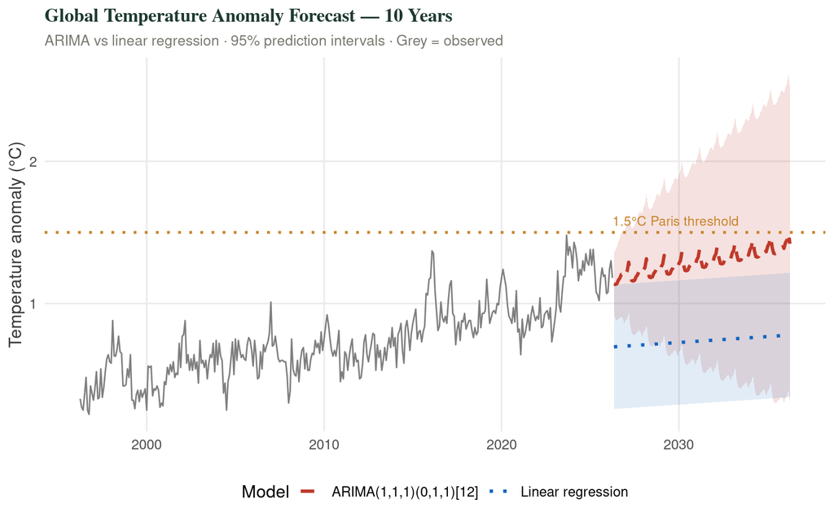

```r
temp_arima_base <- arima(temp_base_ts,
                         order    = c(1, 1, 1),
                         seasonal = list(order = c(0, 1, 1), period = 12))

# ── Linear model for temperature ──────────────────────────────────────────────
temp_df <- tibble(
  t   = as.numeric(time(temp_base_ts)),
  tmp = as.numeric(temp_base_ts)
)
lm_temp <- lm(tmp ~ t, data = temp_df)

h_temp       <- 120   # 10 years
temp_pred    <- predict(temp_arima_base, n.ahead = h_temp)
last_t_temp  <- time(temp_base_ts)[length(temp_base_ts)]
fc_times_t   <- seq(last_t_temp, by = 1/12, length.out = h_temp + 1)[-1]

# ── ARIMA forecast ────────────────────────────────────────────────────────────
fc_temp_df <- tibble(
  t    = fc_times_t,
  fit  = as.numeric(temp_pred$pred),
  lo95 = as.numeric(temp_pred$pred - 1.96 * temp_pred$se),
  hi95 = as.numeric(temp_pred$pred + 1.96 * temp_pred$se)
)

# ── Linear model forecast ─────────────────────────────────────────────────────
lm_temp_fc <- tibble(t = fc_times_t) |>
  mutate(
    fit_lm  = predict(lm_temp, newdata = tibble(t = fc_times_t)),
    se_lm   = summary(lm_temp)$sigma *
                sqrt(1 + 1/nrow(temp_df) +
                     (fc_times_t - mean(temp_df$t))^2 /
                     sum((temp_df$t - mean(temp_df$t))^2)),
    lo95_lm = fit_lm - 1.96 * se_lm,
    hi95_lm = fit_lm + 1.96 * se_lm
  )

hist_temp_df <- tibble(
  t   = as.numeric(time(temp_base_ts)),
  val = as.numeric(temp_base_ts)
) |> filter(t >= last_t_temp - 30)

ggplot() +
  # ARIMA 95% PI
  geom_ribbon(data = fc_temp_df, aes(x = t, ymin = lo95, ymax = hi95),
              fill = ts_red, alpha = 0.15) +
  # Linear model 95% PI
  geom_ribbon(data = lm_temp_fc, aes(x = t, ymin = lo95_lm, ymax = hi95_lm),
              fill = ts_blue, alpha = 0.12) +
  # Historical data
  geom_line(data = hist_temp_df, aes(x = t, y = val),
            color = "grey50", linewidth = 0.5) +
  # ARIMA forecast
  geom_line(data = fc_temp_df, aes(x = t, y = fit,
                                    color = "ARIMA(1,1,1)(0,1,1)[12]"),
            linewidth = 1.1, linetype = "dashed") +
  # Linear model forecast
  geom_line(data = lm_temp_fc, aes(x = t, y = fit_lm,
                                    color = "Linear regression"),
            linewidth = 1.1, linetype = "dotted") +
  # Paris threshold
  geom_hline(yintercept = 1.5, linetype = "dotted",
             color = ts_amber, linewidth = 0.9) +
  annotate("text", x = last_t_temp, y = 1.58,
           label = "1.5°C Paris threshold",
           color = ts_amber, hjust = 0, size = 3.2) +
  scale_color_manual(
    name   = "Model",
    values = c("ARIMA(1,1,1)(0,1,1)[12]" = ts_red,
               "Linear regression"        = ts_blue)
  ) +
  labs(title    = "Global Temperature Anomaly Forecast — 10 Years",
       subtitle = "ARIMA vs linear regression · 95% prediction intervals · Grey = observed",
       x = NULL, y = "Temperature anomaly (°C)") +
  theme(legend.position = "bottom")
```

**⚠️ Critical distinction: statistical forecast vs physical projection** This ARIMA model extrapolates the past statistical pattern into the future. It has no knowledge of emissions scenarios, ocean heat capacity, ice-albedo feedback, or any other physical mechanism. IPCC climate projections are built from coupled atmosphere-ocean general circulation models — fundamentally different tools.  
The ARIMA forecast is useful for: (1) short-horizon operational planning, (2) demonstrating statistical momentum in the record, (3) illustrating how quickly prediction intervals widen. It should *never* be used to make statements like “global temperature will exceed 1.5°C by year X” — that requires physical modelling under specific emissions pathways.

> **Comparing the two models on temperature:** For temperature the difference between linear regression and ARIMA is subtler than for CO2. Unlike CO2, where the curvature is obvious, global mean temperature has fluctuated enough that a straight line is not a terrible description of the 20th-century record. However, the ARIMA model still wins on AIC because it correctly models the month-to-month autocorrelation — meaning its prediction intervals are calibrated honestly, while the linear regression’s are too narrow by an unknown factor.

```r
# AIC table for temperature models
temp_snaive <- arima(temp_base_ts, order = c(0, 0, 0),
                     seasonal = list(order = c(0, 1, 0), period = 12))

tibble(
  Model      = c("Linear regression (OLS)",
                 "Seasonal naive",
                 "ARIMA(1,1,1)(0,1,1)[12]"),
  Parameters = c(2, 1, 4),
  AIC        = round(c(AIC(lm_temp),
                       AIC(temp_snaive),
                       AIC(temp_arima_base)), 2),
  BIC        = round(c(BIC(lm_temp),
                       BIC(temp_snaive),
                       BIC(temp_arima_base)), 2)
) |>
  kable(caption = "AIC/BIC — temperature models. Lower = better fit per parameter used.") |>
  kable_styling(full_width = FALSE)
```

AIC/BIC — temperature models. Lower = better fit per parameter used.

| Model | Parameters | AIC | BIC |
| --- | --- | --- | --- |
| Linear regression (OLS) | 2 | -286.69 | -270.27 |
| Seasonal naive | 1 | -857.97 | -852.50 |
| ARIMA(1,1,1)(0,1,1)[12] | 4 | -2761.32 | -2739.46 |

## 8. Residual Diagnostics — Is the Model Adequate?

### 8.1 What are model residuals and why do they matter?

A model’s **residuals** are the differences between the observed values and the model’s fitted values:

$$e_t = y_t - \hat{y}_t$$

If the model has captured all the systematic structure in the data, the residuals should be **white noise** — random, with no pattern, centred on zero, and with no remaining autocorrelation. If you can still see patterns in the residuals, the model has not fully explained the data and your forecasts and prediction intervals are unreliable.

**Four diagnostic checks:**

1. **Residuals vs time** — should scatter randomly around zero; any trend, cycles, or changing variance indicates model failure
2. **ACF of residuals** — all bars should be within the blue lines; any significant spike means unused structure remains
3. **PACF of residuals** — same; the PACF helps identify what kind of structure is left (AR or MA)
4. **Normal Q-Q plot** — points should follow the diagonal; heavy tails or systematic curves indicate non-normal errors, which can invalidate prediction intervals

### 8.2 CO2 ARIMA residual diagnostics

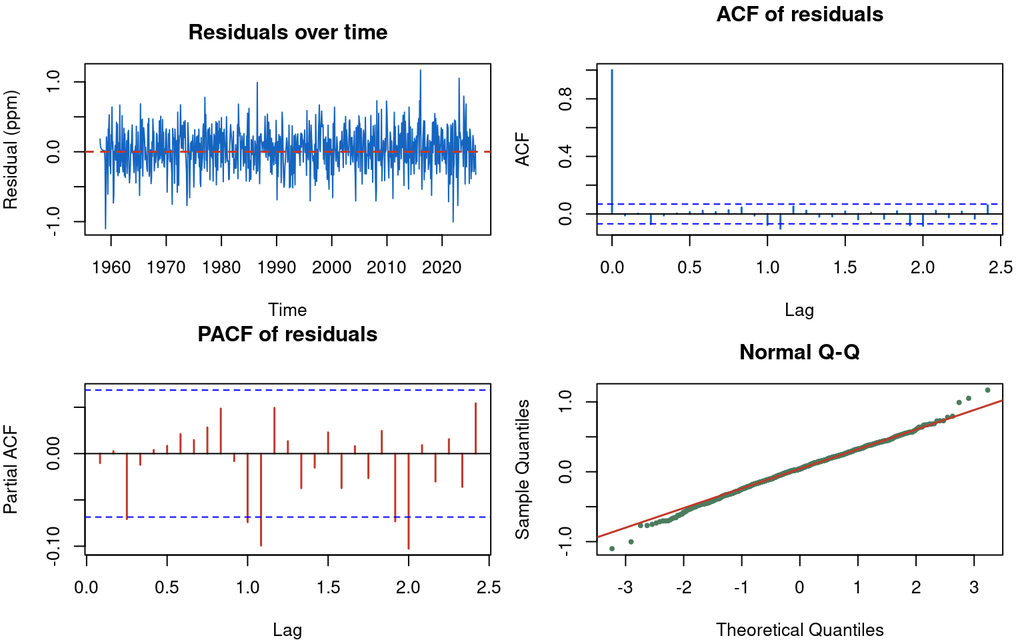

```r
co2_arima_resid <- residuals(co2_arima_base)

par(mfrow = c(2, 2), mar = c(4, 4, 3, 1))
plot(co2_arima_resid, main = "Residuals over time",
     ylab = "Residual (ppm)", col = ts_blue, type = "l")
abline(h = 0, col = ts_red, lty = 2, lwd = 1.5)
acf(co2_arima_resid,  main = "ACF of residuals",  col = ts_blue, lwd = 1.5)
pacf(co2_arima_resid, main = "PACF of residuals", col = ts_red,  lwd = 1.5)
qqnorm(co2_arima_resid, main = "Normal Q-Q", col = ts_sage, pch = 19, cex = 0.5)
qqline(co2_arima_resid, col = ts_red, lwd = 1.5)
```

```r
par(mfrow = c(1, 1))
```

> **What to look for:** - *Top left:* Residuals should bounce around zero with roughly constant spread. A funnel shape (increasing variance over time) suggests the model should be fit on a log scale. - *Top right (ACF):* Ideally all bars within the blue lines. A significant spike at lag 12 means the seasonal model isn’t quite right. - *Bottom left (PACF):* Same logic. A sharp cutoff after lag 1 would suggest adding another AR term. - *Bottom right (Q-Q):* Points close to the diagonal = approximately normal residuals. S-curves or heavy tails mean outlier years are distorting the distribution.

### 8.3 Temperature ARIMA residual diagnostics

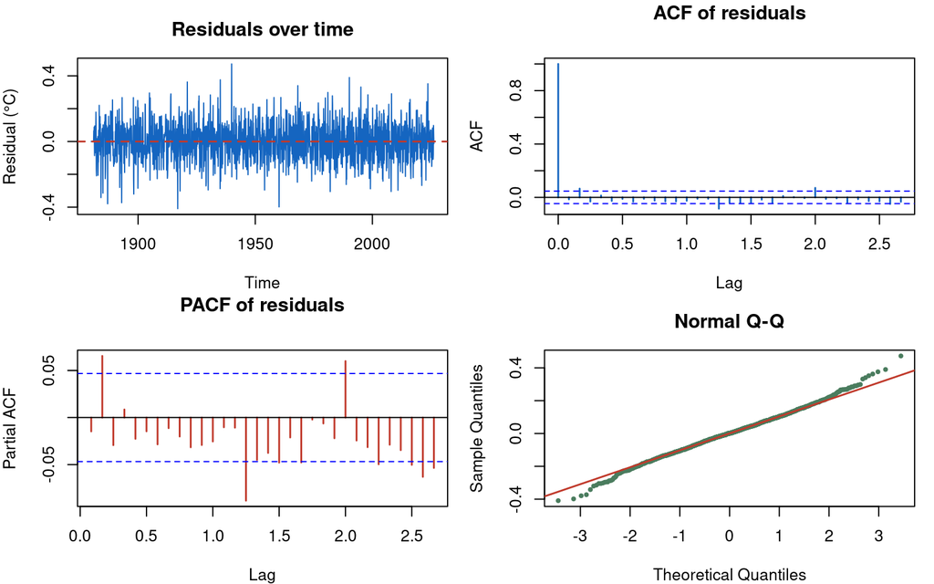

```r
temp_arima_resid <- residuals(temp_arima_base)

par(mfrow = c(2, 2), mar = c(4, 4, 3, 1))
plot(temp_arima_resid, main = "Residuals over time",
     ylab = "Residual (°C)", col = ts_blue, type = "l")
abline(h = 0, col = ts_red, lty = 2, lwd = 1.5)
acf(temp_arima_resid,  main = "ACF of residuals",  col = ts_blue, lwd = 1.5)
pacf(temp_arima_resid, main = "PACF of residuals", col = ts_red,  lwd = 1.5)
qqnorm(temp_arima_resid, main = "Normal Q-Q", col = ts_sage, pch = 19, cex = 0.5)
qqline(temp_arima_resid, col = ts_red, lwd = 1.5)
```

```r
par(mfrow = c(1, 1))
```

> **Temperature-specific interpretation:** Temperature residuals often show larger spikes around major El Niño years (e.g., 1997–1998, 2015–2016). These are genuine climate events that no statistical time series model can anticipate from past data alone — they are by definition anomalies. If you see consistent large residuals for specific decades, that might indicate the warming rate has changed and the model structure needs updating.

### 8.4 Formal Ljung-Box test on model residuals

```r
lb_co2  <- Box.test(co2_arima_resid,  lag = 24, type = "Ljung-Box")
lb_temp <- Box.test(temp_arima_resid, lag = 24, type = "Ljung-Box")

tibble(
  Series   = c("CO2 (Mauna Loa)", "Global temperature anomaly"),
  LB_stat  = round(c(lb_co2$statistic,  lb_temp$statistic), 3),
  df       = c(lb_co2$parameter, lb_temp$parameter),
  p_value  = round(c(lb_co2$p.value, lb_temp$p.value), 4),
  Adequate = ifelse(c(lb_co2$p.value, lb_temp$p.value) > 0.05,
                    "✓ White noise", "✗ Structure remains")
) |>
  kable(
    caption   = "Ljung-Box test on ARIMA model residuals. p > 0.05 means no significant autocorrelation remains.",
    col.names = c("Series", "LB statistic", "df", "p-value", "Adequate?")
  ) |>
  kable_styling(full_width = FALSE)
```

Ljung-Box test on ARIMA model residuals. p > 0.05 means no significant autocorrelation remains.

| Series | LB statistic | df | p-value | Adequate? |
| --- | --- | --- | --- | --- |
| CO2 (Mauna Loa) | 37.739 | 24 | 0.0369 | ✗ Structure remains |
| Global temperature anomaly | 53.035 | 24 | 0.0006 | ✗ Structure remains |

> **If the Ljung-Box test is significant (p < 0.05):** The residuals still contain autocorrelation structure the ARIMA model failed to capture. Options: (1) Increase the AR or MA order (try $p=2$ or $q=2$); (2) Add a seasonal AR term ($P=1$); (3) Fit separate models for different sub-periods if the autocorrelation structure appears to have changed over time; (4) Accept the imperfect fit for exploratory purposes but note the limitation when reporting.

## 9. Extensions and Next Steps

### 9.1 Other environmental time series to explore

The workflow in this module applies directly to many other environmental datasets:

| Dataset | Source | URL | Key patterns |
| --- | --- | --- | --- |
| ENSO (MEI index) | NOAA | `https://www.psl.noaa.gov/enso/mei/` | 3–7 year quasi-periodic cycle |
| Arctic sea ice extent | NSIDC | `https://nsidc.org/arcticseaicenews/` | Strong seasonal cycle + declining trend |
| Pacific Decadal Oscillation | NOAA | `https://www.ncei.noaa.gov/access/monitoring/pdo/` | Decadal variability |
| Stream discharge | USGS NWIS | `dataRetrieval` R package | Flashy events, snowmelt seasonality |
| PM2.5 air quality | EPA AQS | `https://aqs.epa.gov/aqsweb/documents/data_api.html` | Diurnal + seasonal + wildfire spikes |
| Phenology | USA-NPN | `rnpn` R package | Spring onset trends |

### 9.2 When ARIMA is not enough

The airline model works well for many environmental series, but some situations require different approaches:

**Intervention analysis:** If a known event (policy change, volcanic eruption, station relocation) caused a step change or slope change in the series, add an intervention term as a dummy variable in the ARIMA regression component.

**Transfer function models (ARIMAX):** If you believe one time series (e.g., ENSO index) drives another (e.g., California precipitation), include the driver as an exogenous predictor. This becomes `arima(..., xreg = enso_index)`.

**Structural breaks:** If the autocorrelation or trend structure appears to have changed at a specific time (e.g., warming accelerated after 1980), fit separate models to each period and test whether the parameters differ.

**Multiple seasonality:** Hourly environmental data (air quality monitors, stream gauges) has both diurnal (24-hour) and annual seasonality. Base R’s `stl()` handles only one seasonal period at a time — use `stats::HoltWinters()` with multiple seasons or the `forecast` package’s `mstl()`.

### 9.3 Cross-validation for honest forecast accuracy

A single train/test split gives one estimate of forecast accuracy. Rolling-origin cross-validation (also called time-series cross-validation) gives a more robust estimate by repeatedly re-fitting the model as new data become available:

```r
# Rolling-origin cross-validation for ARIMA — base R approach
# Train on first 20 years, test on year 21; then first 21 years, test on year 22...
n      <- length(co2_base_ts)
h      <- 12          # forecast horizon (1 year)
init   <- 12 * 20     # initial training set (20 years)
errors <- numeric(n - init - h + 1)

for (i in seq_along(errors)) {
  train <- co2_base_ts[1:(init + i - 1)]
  test  <- co2_base_ts[(init + i):(init + i + h - 1)]
  fit   <- arima(train,
                 order    = c(1, 1, 1),
                 seasonal = list(order = c(0, 1, 1), period = 12))
  fc    <- predict(fit, n.ahead = h)$pred
  errors[i] <- sqrt(mean((as.numeric(test) - as.numeric(fc))^2))  # RMSE
}

cat("Mean RMSE across", length(errors), "rolling origins:",
    round(mean(errors), 3), "ppm\n")
```

[output not shown]

The resulting mean RMSE gives you a realistic expectation of how well the model will forecast future data — much more honest than in-sample fit statistics.

#### 🔑 Time Series Analysis — key takeaways

- **Autocorrelation is a feature, not a bug.** Time series data is correlated across time by design. Standard statistical tests assume independence and are invalid when applied to raw time series. Use time-series-aware methods that model the correlation structure explicitly.
- **Always plot before modelling.** A simple time-series plot reveals trend, seasonality, outliers, and structural breaks that no model diagnostic will catch. Look at the data first.
- **STL decomposition separates the signal into interpretable parts.** Trend, seasonal, and remainder components each have physical meaning. The relative sizes of the grey bars in the decomposition plot tell you which component dominates.
- **ACF and PACF diagnose model structure.** A slowly decaying ACF → series is non-stationary, needs differencing. PACF cuts off at lag p → AR(p). ACF cuts off at lag q → MA(q). Learn to read these plots — they are the standard language of time series diagnostics.
- **Linear regression on time is almost always the wrong model for time series.** It ignores autocorrelation, which means its standard errors are underestimated and its prediction intervals are too narrow — overconfident in exactly the wrong direction. Use it as an AIC baseline to show what the time-series model gains, not as the final answer.
- **ARIMA(1,1,1)(0,1,1)[12] is a reliable starting point for monthly environmental data** with trend and seasonality. It can be improved, but it is rarely terrible. Always compare against a naive baseline using AIC.
- **Residuals must be white noise.** A model is only adequate when its residuals show no remaining autocorrelation. Check the ACF of residuals and confirm with the Ljung-Box test. Significant residual autocorrelation means your prediction intervals are too narrow.
- **Prediction intervals widen fast — and that is correct.** Uncertainty compounds with each step ahead. Be honest about the rapidly widening bands in your forecasts. A 5-year statistical forecast is an extrapolation, not a prediction. A 10-year forecast should be treated with extreme caution.
- **Statistical forecasts are not physical projections.** ARIMA models learn from past patterns. They cannot anticipate changes in forcing (new emissions policies, volcanic eruptions, ENSO regime shifts). Physical climate models are the right tool for policy analysis.

### What’s next?

- **Signal Over Noise** — the foundation of statistical testing that precedes time-series methods
- **Functional Programming** — use `purrr::map()` to fit models to many stations at once
- **Visualization** — ggplot2 techniques for time-series figures

✏️ Practice Exercises

Exercise 1 — Decomposition

The built-in `AirPassengers` dataset records monthly airline passengers 1949–1960. (a) Plot the raw series. (b) Apply `decompose()` and plot the result. (c) Is the seasonal component additive or multiplicative? How can you tell?

**Show solution**

```
data(AirPassengers)
plot(AirPassengers, main="Monthly airline passengers")
dec <- decompose(AirPassengers, type = "multiplicative")
plot(dec)
```

The seasonal swings get larger as the trend rises — that’s the signature of multiplicative seasonality. With additive seasonality, the swing height would be constant over time.

Exercise 2 — ACF interpretation

Compute and plot `acf()` and `pacf()` on the residuals from the decomposed `AirPassengers` series. What do the plots suggest about remaining structure? Would an AR or MA model be indicated?

**Show solution**

```
resid_ts <- dec$random
acf(resid_ts, na.action = na.pass)
pacf(resid_ts, na.action = na.pass)
```

If the ACF tails off slowly and the PACF cuts off after lag 1–2, an AR(1) or AR(2) model is suggested. If the ACF cuts off sharply after 1–2 lags and PACF tails off, an MA model is indicated.

Mixed Effects Models ↑ Module Index